# Panorama des techniques d’analyse textuelle

## LDA, exemple

La LDA s'applique à la matrice de contingence.

```r
library(RTextTools)
library(slam)
library(topicmodels)
SEED<-123

k <- 3
lda <-
list(VEM = LDA(doc_term, k = k, control = list(seed = SEED)),
 VEM_fixed = LDA(doc_term, k = k,
control = list(estimate.alpha = FALSE, seed = SEED)),
Gibbs = LDA(doc_term, k = k, method = "Gibbs",
control = list(seed = SEED, burnin = 1000,
thin = 100, iter = 1000)),
CTM = CTM(doc_term, k = k, control = list(seed = SEED,
 var = list(tol = 10^-4), em = list(tol = 10^-3))))
```

## Termes représentatifs des thèmes

On peut afficher les termes les plus fréquents de chaque thème.

```r
terms(lda[["CTM"]], 10)
```

```
##       Topic 1          Topic 2         Topic 3
##  [1,] "repression"     "nombre"        "voit"
##  [2,] "problematiques" "deplace"       "personnel"
##  [3,] "delinquance"    "apres"         "rapport"
##  [4,] "quartien"       "interviennent" "personne"
##  [5,] "part"           "bien"          "presence"
##  [6,] "non"            "manquent"      "delinquance"
##  [7,] "preventif"      "delinquants"   "presente"
##  [8,] "arrivent"       "police"        "bonnes"
##  [9,] "laxisme"        "temps"         "arreter"
## [10,] "voit"           "moins"         "non"
```

## Classement des documents

Thèmes par ordre d'importance pour les documents.

```r
topics(lda[["CTM"]], 10)[1:3,1:5]
```

```
##      character(0) character(0) character(0) character(0) character(0)
## [1,]            3            3            3            3            3
## [2,]            1            2            2            1            1
## [3,]            2            1            1            2            2
```

## Distribution a post. des thèmes au sein des documents

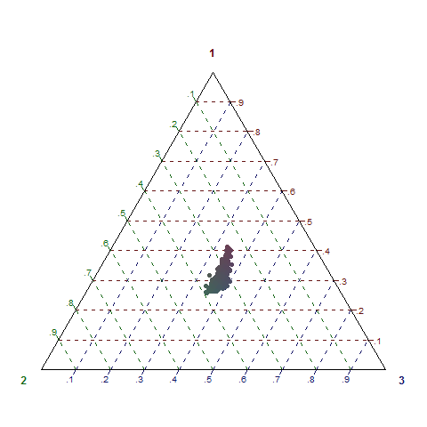

## Distribution a post. des thèmes dans quelques documents

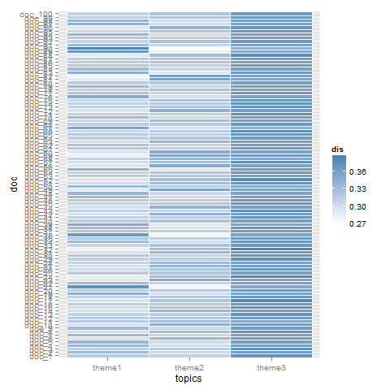

## Distribution a post. des termes dans les thèmes

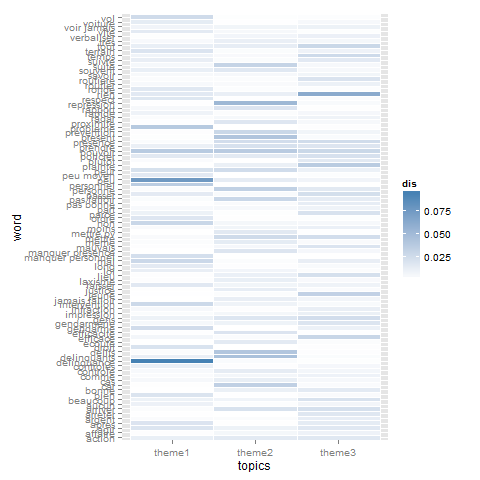

## Distribution a post. des thèmes (Gibbs)

Avec l'algorithme de Gibbs, les différents thèmes ont le mêmes poids en moyenne alors que CTM autorise une corrélation entre les thèmes.

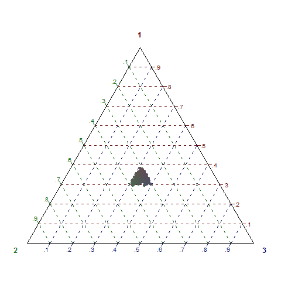

## Distribution a post. des thèmes (Gibbs)

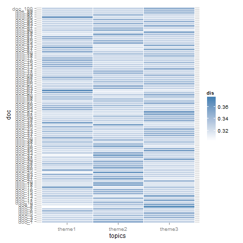

## Distribution a post. des termes (Gibbs)

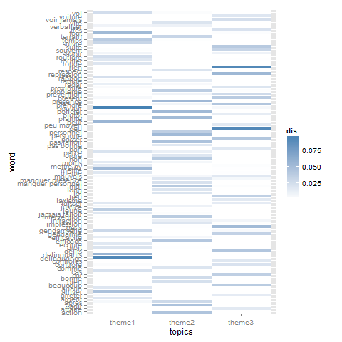

## Réseaux de mots

Il s'agit d'une analyse des **cooccurrences** présentée sous formes de graphiques de mots associés. Les indices de similitudes proposés dans IRaMuTeQ sont ceux disponibles dans la librairie `proxy` de R.

Par défaut, les formes/mots sont les sommets du graphe et les arêtes représentent les cooccurrences entre eux. Plus la taille des mots est grande, plus ils sont fréquents dans le corpus, plus les liens/arêtes sont épais, plus les mots sont cooccurrents.

L'algorithme de fruchterman reingold est utilisé pour optimiser l'affichage du graphe et visualiser les mots le plus « centraux » (mots « types » du corpus). Les formes/mot mots les plus centraux sont détectés à partir du calcul de leur centralité d'intermédiarité. Ces mots servent d'intermédiaires pour relier (au sens de la cooccurrence) un grand nombre d'autres mots entre eux.

## Exemple avec Iramuteq

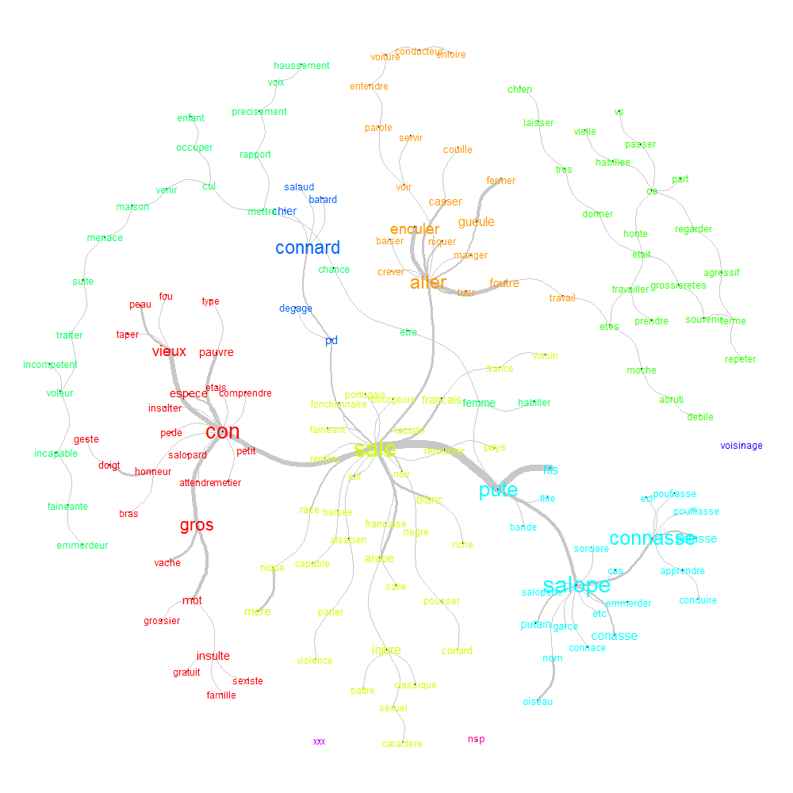

## Clusterisation du réseau

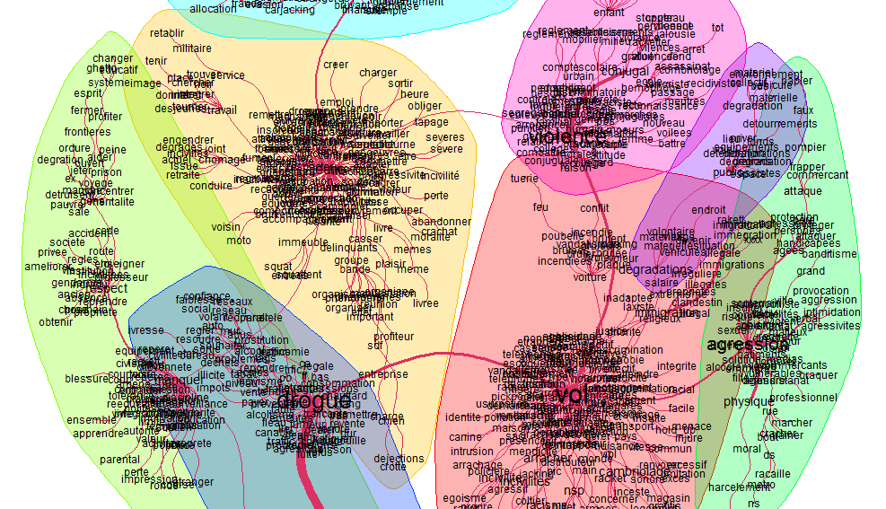

## L'utilisation des variables textuelles dans la modélisation

## Exemple : imputation du sexe de l'agresseur

On peut utiliser les mots comme des indicatrices (ou variables numériques) dans un modèle économétrique classique.

Exemple : imputer le sexe de l'agresseur qui n'est pas parfaitement renseigné dans l'enquête victimation où l'on dispose des insultes utilisées par les agresseurs à l'égard de la victime ainsi qu'un certain nombre de variables (sexe et âge de la victime, agresseur connu de la victime, etc…).

## Exemple : imputation du sexe de l'agresseur

Les matrices de confusion avec ou sans mot sont les suivantes, montre une très légère amélioration de la détection du sexe lorsqu'il s'agit d'un homme (premier test !)

```
##           Reference
## Prediction   h   f
##          h 123  35
##          f  60  31
```

```
##           Reference
## Prediction   h   f
##          h 118  31
##          f  65  35
```

## Exemple : imputation du sexe de l'agresseur

```
##            var        coef                     var        coef
## 1  (Intercept)  1.50838048               incapable -0.91204877
## 2         SEXE  0.51935458                 insulte -0.17587925
## 3     MINASVP5  0.06920952                  menace  0.13413491
## 4     ASCONVP5 -1.02895353                    pede  0.32228578
## 5      AGE.30. -0.05007501                 petasse  0.49345069
## 6         bien -0.80091372                   petit -0.25780054
## 7          car  0.30974481               poufiasse -0.08705926
## 8       casser -0.07008751                regarder  0.65909495
## 9         chez  0.41334960                 rentrer  0.33509777
## 10     conasse  0.24907351                retourne  0.99943584
## 11     connard  0.14264088                 saloper -0.11698971
## 12     couille  0.63509608                    tout -0.61848280
## 13     emmerde -0.64523512                 voiture -0.02907284
## 14     enculer -0.07399753                 vouloir  0.44438015
## 15      espece -0.18286379            saloper pute -0.41548691
## 16        etes  0.84510017       regarder comme ca -0.22356380
## 17        etre -0.91501771 savoir plus precisement  0.44626052
## 18        fait -0.93611785   souhaiter pas repeter  0.02289652
## 19 gros|grosse  0.12382144     souvenir plus terme  0.17075031
## 20     honneur -0.47416860                    <NA>          NA
```

## L'analyse sémantique

## L'analyse sémantique, quelques concepts

L'analyse sémantique vise à prendre également en compte le sens du message via les intéractions entre les mots, leur place et rôle dans la phrase ou les connotations des mots. **Quelques exemples** :

- l'étiquetage (**POS tagging** ou **part-of-speech tagging**)
- **sentiment analysis** ou **opinion mining**.
- l'utilisation d'ontologies (wordnet, réseaux de mots)
- les raisonnements par analogie (**Word2vec**)

La principale difficulté provient de ce que toutes ces approches ne bénéficient pas directement de la recherche internationale en **Natural Language Processing**, les ressources sont dépendantes de la langue et rares…